# DOSBOL ALIEV

# CONCLUSION FOR STEP 3

###### QUESTION

1. What can you conclude from the plots you created?  
2. Are there any interesting findings?

###### ANSWER

# STEP 4

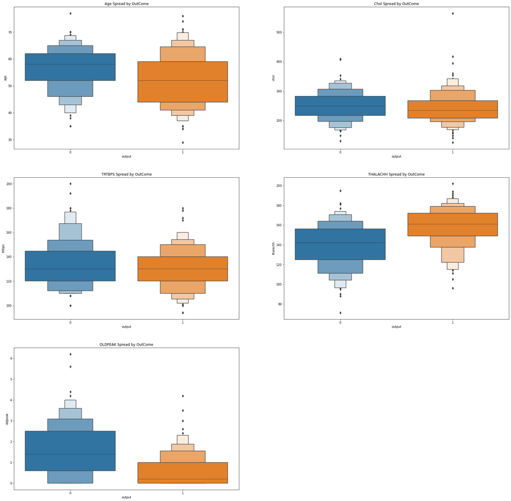

```python
plt. subplots(figsize=(30,30))

plt.subplot(3,2,1)
plt.title('Engine Size vs Price')
sns.boxenplot(y="age",x='output',data=dosbol).set_title('Age Spread by OutCome')

plt.subplot(3,2,2)
plt.title('Boreratio vs Price')
sns.boxenplot(y="chol",x='output',data=dosbol).set_title('Chol Spread by OutCome')

plt.subplot(3,2,3)
plt.title('Boreratio vs Price')
sns.boxenplot(y="trtbps",x='output',data=dosbol).set_title('TRTBPS Spread by OutCome')

plt.subplot(3,2,4)
plt.title('Boreratio vs Price')
sns.boxenplot(y="thalachh",x='output',data=dosbol).set_title('THALACHH Spread by OutCome')

plt.subplot(3,2,5)
plt.title('Boreratio vs Price')
sns.boxenplot(y="oldpeak",x='output',data=dosbol).set_title('OLDPEAK Spread by OutCome')


plt.show()
```

# CONCLUSION FOR STEP 4

#### Question

1. What can you conclude from the plots you created?  
2. Are there any interesting findings?

#### Answer

# STEP 5

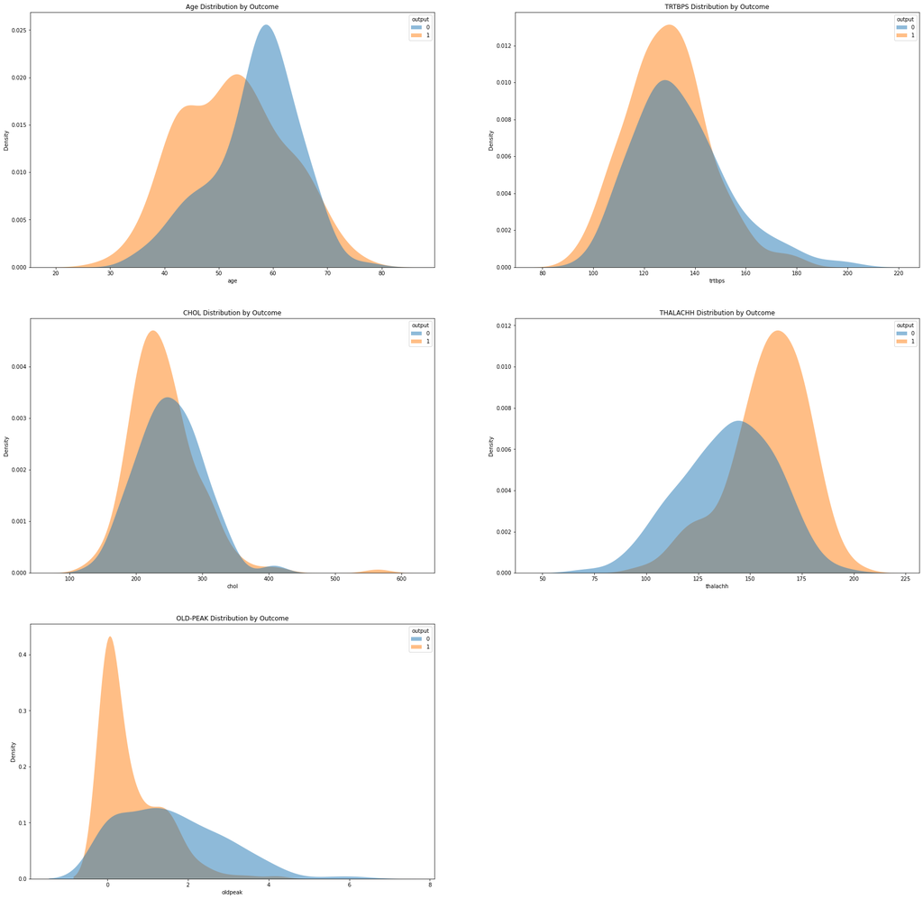

```python
plt. subplots(figsize=(30,30))
plt.subplot(3,2,1)
plt.title('Age Distribution by Outcome')
sns.kdeplot(
   data=dosbol, x="age", hue="output",
   fill=True,
   alpha=.5, linewidth=0,
)


plt.subplot(3,2,2)
plt.title('TRTBPS Distribution by Outcome')
sns.kdeplot(
   data=dosbol, x="trtbps", hue="output",
   fill=True,
   alpha=.5, linewidth=0,
)

plt.subplot(3,2,3)
plt.title('CHOL Distribution by Outcome')
sns.kdeplot(
   data=dosbol, x="chol", hue="output",
   fill=True,
   alpha=.5, linewidth=0,
)

plt.subplot(3,2,4)
plt.title('THALACHH Distribution by Outcome')
sns.kdeplot(
   data=dosbol, x="thalachh", hue="output",
   fill=True,
   alpha=.5, linewidth=0,
)

plt.subplot(3,2,5)
plt.title('OLD-PEAK Distribution by Outcome')
sns.kdeplot(
   data=dosbol, x="oldpeak", hue="output",
   fill=True,
   alpha=.5, linewidth=0,
)


plt.show()
```

# CONCLUSION FOR STEP 5

#### Question

1. What can you conclude from the plots you created?  
2. Are there any interesting findings?

#### Answer

# STEP 6

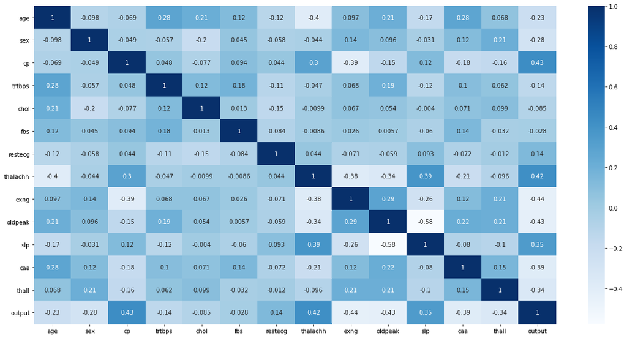

```python
plt.figure(figsize=(20,10))
sns.heatmap(dosbol.corr(), annot=True,cmap="Blues")

plt.show()
```

# CONCLUSION FOR STEP 6

#### Question

1. What can you conclude from the heatmap you created?  
2. Are there any interesting findings?

#### Answer

1. We can conclude that in this HeatMap, the highest Correlation of the two things is 0.43, and the lowest one is -0.58.  
2. Yes, in this heatmap, the correlation between "output" and "cp" is the highest(0.43), so we don't have any correlation that more than 0.50. Also, As we see we don't have a multicollinearity in this HeatMap

# STEP 7

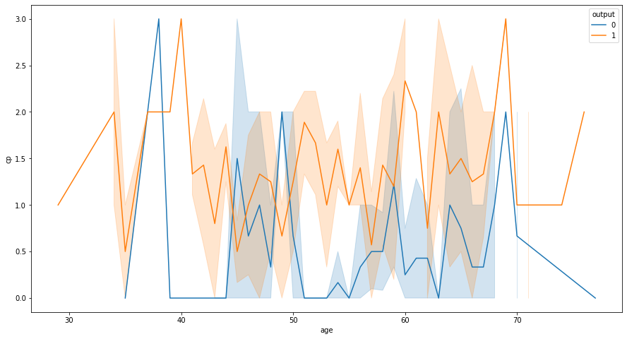

```python
plt.figure(figsize=(15,8))
sns.lineplot(x='age', y='cp', hue='output', data=dosbol)
```

# CONCLUSION FOR STEP 7

#### Question

1. What can you conclude from the plots that you created?  
2. Did you find anything interesting?

#### Answer

1. As we can see, There is No Correlation. In other words, correlation is too weak and has a high variance.  
2. An interesting finding is that variance plays a considerable role here.